# Lista 4

Author

Leonardo Ramos Barbosa - 211010360

Published

December 14, 2023

# Parte 1

Vocês irão trabalhar com alguns bancos de dados nesta avaliação. O banco de dados `def_area_1988_2022.csv` contém dados sobre a área desmatada ($km^2$), entre os anos de 1988 a 2022 para todos os estados da Amazônia Legal, organizados pelo Programa de Monitoramento da Floresta Amazônica Brasileira por Satélite ([PRODES](http://www.obt.inpe.br/OBT/assuntos/programas/amazonia/prodes)). O banco de dados `inpe_brazilian_amazon_fires_1999_2022.csv` contém registros da quantidade de focos de incêndio na Amazônia Legal por estado, mês e ano, de 1999 a 2022. O dados são geridos pelo Instituto Nacional de Pesquisas Espaciais (INPE) em seu programa Banco de Dados de Queimada ([BDQ](https://queimadas.dgi.inpe.br/queimadas/bdqueimadas/)). O conjunto de dados `el_nino_la_nina_1999_2022.csv` contém dados sobre ano de início, ano de fim e severidade de dois dos fenômenos climáticos mais importantes *El Niño* e *La Niña*. Esses dados são organizados pelo [Golden Gate Weather Services](https://ggweather.com/enso/oni.htm). Finalmente, o banco de dados `br_presidents.csv` contém os presidentes brasileiros, por ano, de 1988 a 2022. Este último banco de dados foi resumido em anos pelo Professor James de modo a possibilitar alguma análise anual, conjuntamente aos demais bancos de dados.

Utilize o comando abaixo para carregar o pacote `tidyverse` e carregar os quatro bancos de dados em objetos do `R`.

```r
library( tidyverse )
def_area <- read_csv( "def_area_1988_2022.csv")
fires_amz <- read_csv2( "inpe_brazilian_amazon_fires_1999_2022.csv" )
phenomenon <- read_csv2( "el_nino_la_nina_1999_2022.csv"  )
br_presidents <- read_csv2( "br_presidents.csv" )
```

### Exercício 1

1. Transforme o conjunto de dados `def_area` de tal modo que cada estado da variável `state` passe a ser uma variável. Chame o novo banco de dados de `def_amz`. *Dica: Os dados estão no formato longo.*

#### R:

```r
def_amz <- pivot_wider(def_area, names_from = "state", values_from = "area")
def_amz
```

```
# A tibble: 35 × 11
    year ref         ac    am    ap    ma    mt    pa    ro    rr    to
   <dbl> <chr>    <dbl> <dbl> <dbl> <dbl> <dbl> <dbl> <dbl> <dbl> <dbl>
 1  1988 complete   620  1510    60  2450  5140  6990  2340   290  1650
 2  1989 complete   540  1180   130  1420  5960  5750  1430   630   730
 3  1990 complete   550   520   250  1100  4020  4890  1670   150   580
 4  1991 complete   380   980   410   670  2840  3780  1110   420   440
 5  1992 complete   400   799    36  1135  4674  3787  2265   281   409
 6  1993 complete   482   370     0   372  6220  4284  2595   240   333
 7  1994 complete   482   370     0   372  6220  4284  2595   240   333
 8  1995 complete  1208  2114     9  1745 10391  7845  4730   220   797
 9  1996 complete   433  1023     0  1061  6543  6135  2432   214   320
10  1997 complete   358   589    18   409  5271  4139  1986   184   273
# ℹ 25 more rows
```

### Exercício 2

2. Crie uma nova variável no banco de dados `def_amz` chamada `deforestation`, com o desmatamento em toda a Amazônia Legal.

#### R:

```r
def_amz <- def_amz %>%
  mutate(deforestation = rowSums(select(., ac:to), na.rm = TRUE))
def_amz
```

```
# A tibble: 35 × 12
    year ref         ac    am    ap    ma    mt    pa    ro    rr    to
   <dbl> <chr>    <dbl> <dbl> <dbl> <dbl> <dbl> <dbl> <dbl> <dbl> <dbl>
 1  1988 complete   620  1510    60  2450  5140  6990  2340   290  1650
 2  1989 complete   540  1180   130  1420  5960  5750  1430   630   730
 3  1990 complete   550   520   250  1100  4020  4890  1670   150   580
 4  1991 complete   380   980   410   670  2840  3780  1110   420   440
 5  1992 complete   400   799    36  1135  4674  3787  2265   281   409
 6  1993 complete   482   370     0   372  6220  4284  2595   240   333
 7  1994 complete   482   370     0   372  6220  4284  2595   240   333
 8  1995 complete  1208  2114     9  1745 10391  7845  4730   220   797
 9  1996 complete   433  1023     0  1061  6543  6135  2432   214   320
10  1997 complete   358   589    18   409  5271  4139  1986   184   273
# ℹ 25 more rows
# ℹ 1 more variable: deforestation <dbl>
```

### Exercício 3

3. Observe que, na variável `ref`, o ano de 2022 apresenta o resultado *until November*. Isso indica que os dados estão disponíveis apenas até 30/11/2022. Nós tentaremos melhorar esses resultados através de uma estimativa. Vamos completar a medida desses anos adicionando o que corresponderia a um mês médio daquele ano. Você pode realizar isso da maneira que preferir, mas abaixo deixo duas sugestões. Crie um novo *dataframe* auxiliar denominado `def_new_2022`, que terá apenas uma linha. Neste novo conjunto de dados, a primeira coluna deve conter o ano de 2022, e a segunda, o texto *“complete estimate”*. As demais variáveis serão compostas pelos valores do conjunto original para o ano de 2022, acrescidos de 1/11 avos (arredondado para o número inteiro mais próximo) do valor presente. Dessa forma, tentaremos atualizar o valor das variáveis para incluir uma estimativa de dezembro, baseada na média dos meses anteriores. Em seguida, substitua, no banco `def_amz`, a linha do ano de 2022 por `def_new_2022`.

#### R:

```r
def_new_2022 <- def_amz %>%
  filter(year == "2022") %>%
  mutate(across(where(is.numeric) & !year, ~ . + round(. / 11))) %>%
  mutate(ref = "complete estimate")

def_amz <- def_amz %>%
  filter(year != 2022) %>%
  bind_rows(def_new_2022)
tail(def_amz)
```

```
# A tibble: 6 × 12
   year ref                  ac    am    ap    ma    mt    pa    ro    rr    to
  <dbl> <chr>             <dbl> <dbl> <dbl> <dbl> <dbl> <dbl> <dbl> <dbl> <dbl>
1  2017 complete            257  1001    24   265  1561  2433  1243   132    31
2  2018 complete            444  1045    24   253  1490  2744  1316   195    25
3  2019 complete            682  1434    32   237  1702  4172  1257   590    23
4  2020 complete            706  1512    24   336  1779  4899  1273   297    25
5  2021 complete            889  2306    17   350  2213  5238  1673   315    37
6  2022 complete estimate   924  2844     7   308  2079  4517  1649   262    29
# ℹ 1 more variable: deforestation <dbl>
```

### Exercício 4

4. Para o banco de dados `fires_amz`, selecione apenas as variáveis `year` e `total`. Em seguida, mude o nome da variável `total` para `fires`.

#### R:

```r
fires_amz <- fires_amz %>%
  select(year, total) %>%
  rename(fires = total)
fires_amz
```

```
# A tibble: 25 × 2
    year fires
   <dbl> <dbl>
 1  1998  3194
 2  1999  5458
 3  2000  4127
 4  2001  2913
 5  2002  4150
 6  2003  5597
 7  2004  4333
 8  2005  3832
 9  2006  5367
10  2007  4476
# ℹ 15 more rows
```

### Exercício 5

5. Selecione apenas as variáveis `year` e `deforestation` do banco de dados `def_amz` e as una aos bancos de dados `fires_amz`, `phenomenon` e `br_presidents`, formando um único banco de dados nomeado `degradation`.

#### R:

```r
degradation <- def_amz %>%
  select(year, deforestation) %>%
  left_join(fires_amz, by = "year") %>%
  left_join(phenomenon, by = "year") %>%
  left_join(br_presidents, by = "year")
degradation
```

```
# A tibble: 35 × 6
    year deforestation fires phenomenon severity president
   <dbl>         <dbl> <dbl> <chr>      <chr>    <chr>
 1  1988         21050    NA <NA>       <NA>     Sarney
 2  1989         17770    NA <NA>       <NA>     Sarney
 3  1990         13730    NA <NA>       <NA>     Sarney / Collor
 4  1991         11030    NA <NA>       <NA>     Collor
 5  1992         13786    NA <NA>       <NA>     Collor
 6  1993         14896    NA <NA>       <NA>     Itamar
 7  1994         14896    NA <NA>       <NA>     Itamar
 8  1995         29059    NA <NA>       <NA>     FHC
 9  1996         18161    NA <NA>       <NA>     FHC
10  1997         13227    NA <NA>       <NA>     FHC
# ℹ 25 more rows
```

### Exercício 6

6. Apresente o desflorestamento médio, por governo, em ordem decrescente. O que você avalia?

#### R:

```r
president_avg <- degradation %>%
  group_by(president) %>%
  summarise(avg_deforestation = mean(deforestation, na.rm = TRUE)) %>%
  arrange(desc(avg_deforestation))
president_avg
```

```
# A tibble: 10 × 2
   president       avg_deforestation
   <chr>                       <dbl>
 1 Sarney                     19410
 2 FHC                        19141.
 3 Lula                       15687.
 4 Itamar                     14896
 5 Sarney / Collor            13730
 6 Collor                     12408
 7 Bolsonaro                  11660.
 8 Dilma / Temer               7893
 9 Temer                       7242.
10 Dilma                       5620.
```

Podemos observar que durante o governo Dilma o desmatamento foi o mais baixo, enquanto no governo Sarney foi o mais alto. Isso provavelmente se deve ao fato de que o meio ambiente ganhou mais relevância a partir do século XXI. Apesar disso, após o período de governo Dilma, a média voltou a subir.

# Parte 2

Vocês irão aprender aqui como adicionar, aos seus gráficos, linhas verticais por meio da geometria `geom_vline` e textos por meio do comando `annotate`. Lembre-se, para qualquer dúvida sempre há o **help**. O comando abaixo gera um gráfico de linhas ao longo do tempo com linhas verticais pontilhadas exatamente na troca dos governos. Além disso, adicionamos o nome dos presidentes que atuaram durante o período.

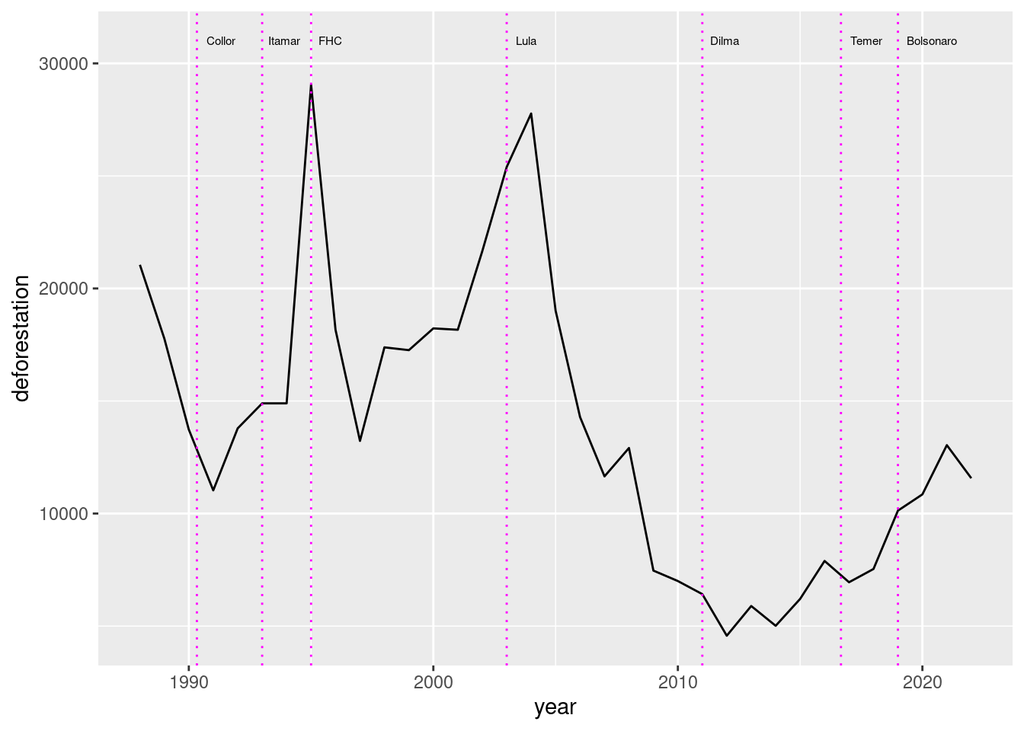

```r
def_area %>%
  pivot_wider( names_from = "state",
               values_from = "area" ) %>%
  mutate( deforestation = ac + am + ap + ma + mt + pa + ro + rr + to ) %>%
  select( year, deforestation ) %>%
  left_join( fires_amz, by = "year" ) %>%
  left_join( phenomenon, by = "year" ) %>%
  left_join( br_presidents, by = "year" ) %>%
  ggplot( aes( year, deforestation ) ) +
  geom_line() +
  geom_vline( xintercept = c(1990.33, 1993, 1995, 2003, 2011, 2016.67, 2019),
              color = "magenta", linetype = 3 ) +
  annotate( "text",
            x = c(1991.3, 1993.9, 1995.8, 2003.8, 2011.9, 2017.7, 2020.4),
            y = 31000,
            label = c("Collor", "Itamar", "FHC", "Lula", "Dilma", "Temer", "Bolsonaro"),
            size = 2)
```

*El Niño* e *La Niña* são fenômenos climáticos importantes que podem afetar o regime de chuvas e, consequentemente, focos de incêndio e desmatamento. Nos exercícios seguintes, você irão realizar alguma análise, superficial, sobre esses fenômenos.

### Exercício 7

7. Faça um **boxplot** do fenômeno contra as queimadas a partir de 1999 (uma vez que não há dados anteriormente a essa data). O que você observa?

#### R:

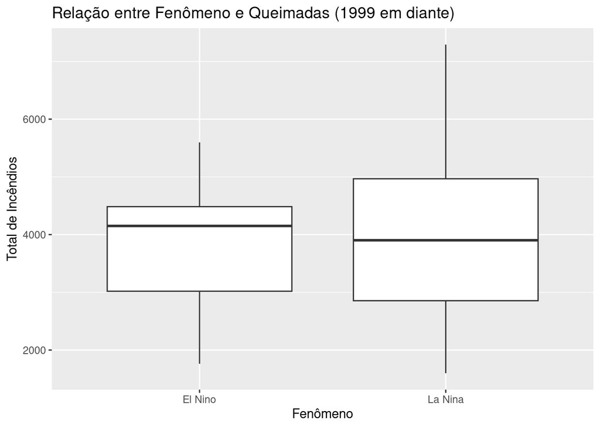

```r
phenomenon_fires <- inner_join(fires_amz, phenomenon, by = "year") %>%
  filter(year >= 1999)

ggplot(phenomenon_fires, aes(x = phenomenon, y = fires)) +
  geom_boxplot() +
  labs(title = "Relação entre Fenômeno e Queimadas (1999 em diante)",
       x = "Fenômeno",
       y = "Total de Incêndios")
```

Vemos que a mediana de incêndios durante o *El Niño* é maior que durante a *La Niña*, porém a variação é maior durante a *La Niña* e os maiores incêndios ocorreram durante a *La Niña*.

### Exercício 8

8. Atribua o tipo `factor` à variável `severity`. Em seguida ordene os níveis da variável por meio do comando `ordered`. Consulte o **help**. Você também pode utilizar as funções do pacote `forcats` como o `fct_relevel()`, ou a função `factor()`acrescentando o parâmetro “levels”.

#### R:

```r
phenomenon_fires$severity <- factor(phenomenon_fires$severity)
phenomenon_fires$severity <- ordered(phenomenon_fires$severity,
                                     levels = c("Weak",
                                                "Moderate",
                                                "Strong",
                                                "Very Strong"))
```

### Exercício 9

9. Faça um **boxplot** da severidade contra as queimadas separado por fenômeno. Lembre-se que não há dados antes de 1999. O que você observa?

#### R:

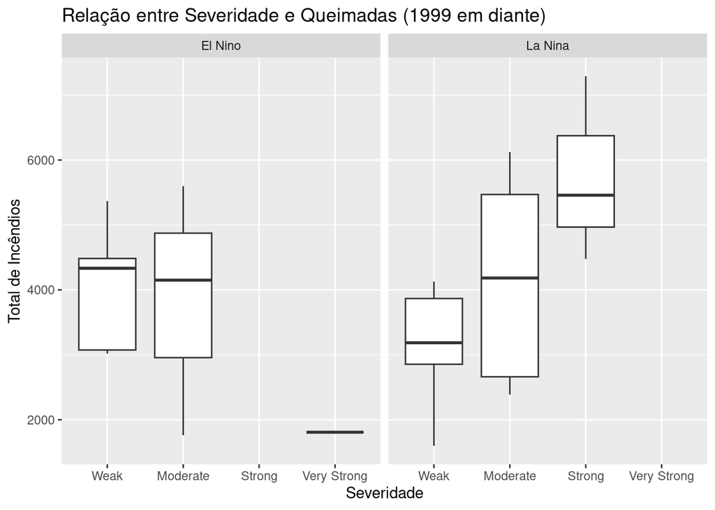

```r
ggplot(phenomenon_fires, aes(x = severity, y = fires)) +
  geom_boxplot() +
  facet_wrap(~ phenomenon) +
  labs(title = "Relação entre Severidade e Queimadas (1999 em diante)",
       x = "Severidade",
       y = "Total de Incêndios")
```

### Exercício 10

10. Apresente um gráfico com a severidade de cada fenômeno, para cada governo, a partir de 1999. Para uma melhor visualização adicione os argumentos `fig.height=4` e `fig.width=10` ao *chunk*.

#### R:

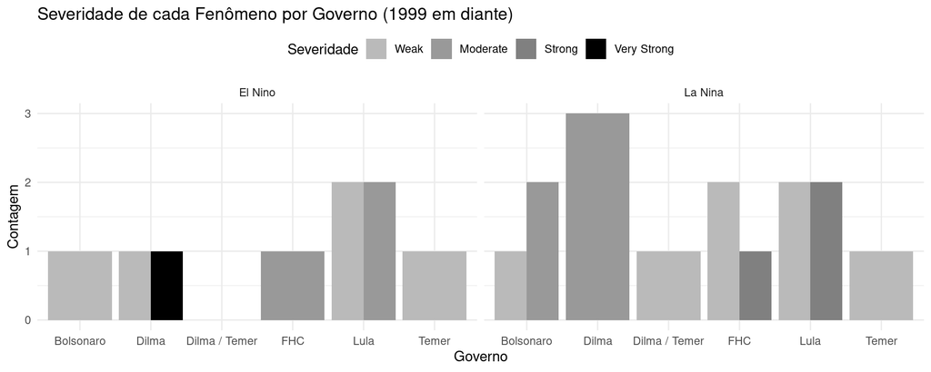

```r
phenomenon_fires_presidents <- inner_join(phenomenon_fires,
                                          br_presidents, by = "year") %>%
  filter(year >= 1999)

ggplot(phenomenon_fires_presidents, aes(x = president, fill = severity)) +
  geom_bar(position = "dodge") +
  facet_wrap(~phenomenon) +
  labs(title = "Severidade de cada Fenômeno por Governo (1999 em diante)",
       x = "Governo",
       y = "Contagem") +
  theme_minimal() +
  theme(legend.position = "top") +
  scale_fill_manual(values = c("Weak" = "#bababa", "Moderate" = "#999999",
                               "Strong" = "#808080", "Very Strong" = "#000000")) +
  guides(fill = guide_legend(title = "Severidade"))
```